# Livestock Growth Modelling Analysis

Yusuf Omotosho

2024-05-23

### Project Overview

This project was conducted for the Department of Animal Breeding & Genetics at the University of Ibadan. The study focused on modeling livestock growth performance using non-linear regression models to analyze growth patterns of Holstein Friesian and F1 crossbred cattle. The analysis provided insights for improved livestock management.

**Objectives:**

- Assess growth performance using non-linear regression models.
- Estimate model parameters and compare growth patterns.
- Provide data-driven recommendations for livestock management.

**Tools & Libraries Used**

- R Packages: nls, minpack.lm, ggplot2, dplyr, readxl
- Software: R, Excel
- Statistical Methods: AIC, BIC, R-squared

### Install and Load Packages

[output not shown]

```
##   These will not be installed
```

```
## installing the source package 'tidyverse'
```

### Data and Methodology

**1. Data Source and Structure :**

```r
# Load dataset
cattle_data <- read_excel("cattle_dataset.xlsx")

# Display a preview of the dataset
print(head(cattle_data))
```

```
## # A tibble: 6 × 4
##      ID Age_Months Breed_Group Weight_Kg
##   <dbl>      <dbl> <chr>           <dbl>
## 1     1        5.5 HYBRID           93.7
## 2     2        6   HYBRID           95.1
## 3     3        6.5 HYBRID          100
## 4     4        7   HYBRID          109.
## 5     5        7.5 HYBRID          110.
## 6     6        8   HYBRID          120.
```

```r
# Inspect the structure of the dataset
cat("\nStructure of the Data:\n")
```

```
##
## Structure of the Data:
```

```r
str(cattle_data)
```

```
## tibble [79 × 4] (S3: tbl_df/tbl/data.frame)
##  $ ID         : num [1:79] 1 2 3 4 5 6 7 8 9 10 ...
##  $ Age_Months : num [1:79] 5.5 6 6.5 7 7.5 8 8.5 9 9.5 10 ...
##  $ Breed_Group: chr [1:79] "HYBRID" "HYBRID" "HYBRID" "HYBRID" ...
##  $ Weight_Kg  : num [1:79] 93.7 95.1 100 109.3 110.3 ...
```

```r
# Summary statistics for each variable
cat("\nSummary Statistics for Each Variable:\n")
```

```
##
## Summary Statistics for Each Variable:
```

```r
print(summary(cattle_data))
```

```
##        ID         Age_Months    Breed_Group          Weight_Kg
##  Min.   : 1.0   Min.   : 5.50   Length:79          Min.   : 93.73
##  1st Qu.:20.5   1st Qu.:10.50   Class :character   1st Qu.:157.26
##  Median :40.0   Median :15.50   Mode  :character   Median :220.02
##  Mean   :40.0   Mean   :15.40                      Mean   :213.43
##  3rd Qu.:59.5   3rd Qu.:20.25                      3rd Qu.:262.75
##  Max.   :79.0   Max.   :26.00                      Max.   :325.33
```

```
##
## Summary of Breed Types and Their Occurrences:
```

```
## # A tibble: 2 × 2
##   Breed_Group Occurrences
##   <chr>             <int>
## 1 HYBRID               38
## 2 PURE BREED           41
```

**2. Data Quality Checks**

```r
# Display any rows with non-finite values for diagnostic purposes
non_finite_rows <- cattle_data %>%
  filter(
    !is.finite(Age_Months) |  # Check for non-finite Age
    !is.finite(Weight_Kg) # Check for non-finite Weight
  )

if (nrow(non_finite_rows) > 0) {
  message("Non-finite values detected. Below are the rows with issues:")
  print(non_finite_rows)
} else {
  message("No non-finite values detected.")
}
```

```
## No non-finite values detected.
```

```r
# Check for missing values
cat("Missing Values:\n")
```

```
## Missing Values:
```

```r
print(colSums(is.na(cattle_data)))
```

```
##          ID  Age_Months Breed_Group   Weight_Kg
##           0           0           0           0
```

```r
# Check for duplicate rows
cat("Duplicate Rows:\n")
```

```
## Duplicate Rows:
```

```r
print(nrow(cattle_data) - nrow(distinct(cattle_data)))
```

```
## [1] 0
```

```r
# Check for outliers using Z-score method
z_scores_Weight <- scale(cattle_data$Weight_Kg)
outliers_Weight <- which(abs(z_scores_Weight) > 3)
cat("Outliers Detected (Weight):\n")
```

```
## Outliers Detected (Weight):
```

```r
print(outliers_Weight)
```

```
## integer(0)
```

```r
z_scores_age <- scale(cattle_data$Age_Months)
outliers_age <- which(abs(z_scores_age) > 3)
cat("Outliers Detected (Age):\n")
```

```
## Outliers Detected (Age):
```

```r
print(outliers_age)
```

```
## integer(0)
```

### Growth Curve Modeling

**Where:**

- ‘Y(t)’ is the population mean at time t.
- ‘A’ is the asymptotic weight or maximum value.
- ‘B’ is the proportion of asymptotic weight to be gained after birth.
- ‘k’ is the maturity rate.
- ‘t’ is time.

**1. Model Fitting**

```r
# Define growth model equations
brody_model <- function(Age_Months, A, B, k) A * (1 - B * exp(-k * Age_Months))
vonB_model <- function(Age_Months, A, B, k) A * (1 - exp(-k * Age_Months))^B
log_model <- function(Age_Months, A, B, k) A / (1 + B * exp(-k * Age_Months))
```

```r
# Fit models for each group
fit_model <- function(model_func, data) {
  nlsLM(Weight_Kg ~ model_func(Age_Months, A, B, k),
        data = cattle_data,
        start = list(A = 730, B = 0.5, k = 0.01),
        control = nls.lm.control(maxiter = 1000))
}


fits <- cattle_data %>%
  group_by(Breed_Group) %>%
  summarise(
    brody = list(fit_model(brody_model, pick(everything()))),
    vonB = list(fit_model(vonB_model, pick(everything()))),
    log = list(fit_model(log_model, pick(everything())))
  )
print(fits)
```

```
## # A tibble: 2 × 4
##   Breed_Group brody  vonB   log
##   <chr>       <list> <list> <list>
## 1 HYBRID      <nls>  <nls>  <nls>
## 2 PURE BREED  <nls>  <nls>  <nls>
```

**3. Parameter Estimation**

```r
extract_params <- function(model) {
  summary(model)$coefficients
}

params <- fits %>%
  mutate(
    brody_params = lapply(brody, extract_params),
    vonB_params = lapply(vonB, extract_params),
    log_params = lapply(log, extract_params)
  )

params_upd <- as.data.frame(lapply(params, function(x) {
  gsub("[^[:print:]]", "", x)
}))

# Extract only the required parameter columns
params_selected <- params_upd %>%
  select(brody_params, vonB_params, log_params) %>%     # Keep only parameter columns
  mutate(
    brody_params = sapply(brody_params, paste, collapse = ", "),  # Convert lists to strings
    vonB_params  = sapply(vonB_params, paste, collapse = ", "),
    log_params   = sapply(log_params, paste, collapse = ", ")
  )

# Print the filtered and formatted results
print(params_selected)
```

```
##                                                                                                                                                                                                                                 brody_params
## 1 c(408.912537117573, 1.05974311888906, 0.0548856045440213, 36.8980212702576, 0.0502805675258656, 0.0104686980470006, 11.0822348472975, 21.0765942199022, 5.2428300346046, 1.55272017695155e-17, 1.77488667411735e-33, 1.37703728834669e-06)
## 2 c(408.912537117573, 1.05974311888906, 0.0548856045440213, 36.8980212702576, 0.0502805675258656, 0.0104686980470006, 11.0822348472975, 21.0765942199022, 5.2428300346046, 1.55272017695155e-17, 1.77488667411735e-33, 1.37703728834669e-06)
##                                                                                                                                                                                                                               vonB_params
## 1 c(377.130500298325, 1.30112447901592, 0.0718192890823641, 32.3888033257671, 0.184423462308713, 0.0166077835787844, 11.643854096897, 7.05509192121078, 4.32443551191921, 1.43419747175708e-18, 6.913347227641e-10, 4.58717640524704e-05)
## 2 c(377.130500298325, 1.30112447901592, 0.0718192890823641, 32.3888033257671, 0.184423462308713, 0.0166077835787844, 11.643854096897, 7.05509192121078, 4.32443551191921, 1.43419747175708e-18, 6.913347227641e-10, 4.58717640524704e-05)
##                                                                                                                                                                                                                               log_params
## 1 c(317.64308423324, 5.96718375048746, 0.172983283071188, 8.81871607675319, 0.545046478373434, 0.0123968081315911, 36.0191984262393, 10.9480273467598, 13.9538566084902, 1.61056464603001e-49, 2.75622272765513e-17, 1.162147834683e-22)
## 2 c(317.64308423324, 5.96718375048746, 0.172983283071188, 8.81871607675319, 0.545046478373434, 0.0123968081315911, 36.0191984262393, 10.9480273467598, 13.9538566084902, 1.61056464603001e-49, 2.75622272765513e-17, 1.162147834683e-22)
```

### Model Comparison

**Assessment Criteria** - ‘AIC (Akaike Information Criterion) - ’BIC’ (Bayesian Information Criterion) - ‘R-squared’

**1. Retrieve residuals and fitted values:**

```r
compare_models <- function(model) {
  # Handle non-converged models
  if (!model$convInfo$isConv) {
    return(c(AIC = NA, BIC = NA, R2 = NA))
  }

  # Extract residuals and fitted values using functions
  residuals <- model$m$resid()  # Residuals
  fitted <- model$m$fitted()   # Fitted values

  # Calculate actual values as fitted + residuals
  actuals <- fitted + residuals

  # Compute metrics
  AIC_val <- AIC(model)
  BIC_val <- BIC(model)
  R2_val <- 1 - sum(residuals^2) / sum((actuals - mean(actuals))^2)

  return(c(AIC = AIC_val, BIC = BIC_val, R2 = R2_val))
}

# Extract metrics for each model and ensure numeric values are displayed
model_metrics <- fits %>%
  rowwise() %>%
  mutate(
    brody_metrics = list(as.numeric(compare_models(brody))),  # Convert to numeric vector
    vonB_metrics  = list(as.numeric(compare_models(vonB))),
    log_metrics   = list(as.numeric(compare_models(log)))
  ) %>%
  unnest_wider(brody_metrics, names_sep = "_") %>%  # Flatten metrics into separate columns
  unnest_wider(vonB_metrics, names_sep = "_") %>%
  unnest_wider(log_metrics, names_sep = "_") %>%
  ungroup()

# Print the cleaned-up metrics
print(model_metrics)
```

```
## # A tibble: 2 × 13
##   Breed_Group brody  vonB  log   brody_metrics_1 brody_metrics_2 brody_metrics_3
##   <chr>       <list> <lis> <lis>           <dbl>           <dbl>           <dbl>
## 1 HYBRID      <nls>  <nls> <nls>            650.            659.           0.949
## 2 PURE BREED  <nls>  <nls> <nls>            650.            659.           0.949
## # ℹ 6 more variables: vonB_metrics_1 <dbl>, vonB_metrics_2 <dbl>,
## #   vonB_metrics_3 <dbl>, log_metrics_1 <dbl>, log_metrics_2 <dbl>,
## #   log_metrics_3 <dbl>
```

**2. Check for Non-convergence**

```r
# Function to check convergence
check_convergence <- function(model) {
  if (is.null(model)) return(data.frame(Status = "Error: Model is NULL"))

  conv_info <- tryCatch(model$convInfo, error = function(e) NULL)
  if (is.null(conv_info)) return(data.frame(Status = "Error: No convergence info"))

  residuals <- tryCatch(residuals(model), error = function(e) NA)
  fitted <- tryCatch(fitted(model), error = function(e) NA)
  actuals <- fitted + residuals

  # Calculate R2 if residuals and fitted values are valid
  R2 <- if (!anyNA(residuals) && !anyNA(fitted)) {
    1 - sum(residuals^2) / sum((actuals - mean(actuals))^2)
  } else {
    NA
  }

  # Return details as a data frame
  data.frame(
    Status = if (conv_info$isConv) "Converged" else "Not Converged",
    Iterations = conv_info$finIter,
    Tolerance = conv_info$finTol,
    StopCode = conv_info$stopCode,
    StopMessage = conv_info$stopMessage,
    R2 = R2
  )
}

# Extract coefficients
extract_coefficients <- function(model) {
  tryCatch(as.numeric(coef(model)), error = function(e) NA)
}

# Apply convergence checks and extract details
convergence_results <- fits %>%
  rowwise() %>%
  mutate(
    brody_check = list(check_convergence(brody)),
    vonB_check = list(check_convergence(vonB)),
    log_check = list(check_convergence(log)),
    brody_coeff = list(extract_coefficients(brody)),
    vonB_coeff = list(extract_coefficients(vonB)),
    log_coeff = list(extract_coefficients(log))
  ) %>%
  unnest_wider(brody_check, names_sep = "_") %>%  # Flatten convergence details
  unnest_wider(vonB_check, names_sep = "_") %>%
  unnest_wider(log_check, names_sep = "_") %>%
  unnest_longer(brody_coeff, values_to = "Brody_Param") %>% # Convert coefficients to rows
  unnest_longer(vonB_coeff, values_to = "vonB_Param") %>%
  unnest_longer(log_coeff, values_to = "Log_Param") %>%
  ungroup()

# Print results
print(convergence_results)
```

```
## # A tibble: 54 × 25
##    Breed_Group brody  vonB   log    brody_check_Status brody_check_Iterations
##    <chr>       <list> <list> <list> <chr>                               <int>
##  1 HYBRID      <nls>  <nls>  <nls>  Converged                               8
##  2 HYBRID      <nls>  <nls>  <nls>  Converged                               8
##  3 HYBRID      <nls>  <nls>  <nls>  Converged                               8
##  4 HYBRID      <nls>  <nls>  <nls>  Converged                               8
##  5 HYBRID      <nls>  <nls>  <nls>  Converged                               8
##  6 HYBRID      <nls>  <nls>  <nls>  Converged                               8
##  7 HYBRID      <nls>  <nls>  <nls>  Converged                               8
##  8 HYBRID      <nls>  <nls>  <nls>  Converged                               8
##  9 HYBRID      <nls>  <nls>  <nls>  Converged                               8
## 10 HYBRID      <nls>  <nls>  <nls>  Converged                               8
## # ℹ 44 more rows
## # ℹ 19 more variables: brody_check_Tolerance <dbl>, brody_check_StopCode <int>,
## #   brody_check_StopMessage <chr>, brody_check_R2 <dbl>,
## #   vonB_check_Status <chr>, vonB_check_Iterations <int>,
## #   vonB_check_Tolerance <dbl>, vonB_check_StopCode <int>,
## #   vonB_check_StopMessage <chr>, vonB_check_R2 <dbl>, log_check_Status <chr>,
## #   log_check_Iterations <int>, log_check_Tolerance <dbl>, …
```

### Visualization

```r
plot_growth <- function(model_func, model, data, title) {
  # Prepare prediction data
  pred_data <- data.frame(Age_Months = seq(min(data$Age_Months), max(data$Age_Months), length.out = 100))
  pred_data$Weight_Kg <- predict(model, newdata = pred_data)

  # Create plot
  ggplot(data, aes(x = Age_Months, y = Weight_Kg, color = Breed_Group)) +
    geom_point(size = 2, alpha = 0.7) +
    geom_smooth(method = "loess", se = FALSE, color = "grey", linetype = "dashed") +
    geom_line(data = pred_data, aes(x = Age_Months, y = Weight_Kg), linewidth = 1.2, color = "blue") +
    labs(
      title = title,
      subtitle = "Fitted Growth Model with Observed Data",
      x = "Age (months)",
      y = "Weight (kg)"
    ) +
    theme_minimal(base_size = 14) +
    theme(
      plot.title = element_text(hjust = 0.5, face = "bold"),
      plot.subtitle = element_text(hjust = 0.5),
      legend.position = "bottom"
    )
}

plots <- fits %>%
  rowwise() %>%
  mutate(
    brody_plot = list(plot_growth(brody_model, brody, cattle_data, paste((Group = factor(Breed_Group)), "- Brody Model"))),
    vonB_plot = list(plot_growth(vonB_model, vonB, cattle_data, paste((Group = factor(Breed_Group)), "- Von Bertalanffy Model"))),
    log_plot = list(plot_growth(log_model, log, cattle_data, paste((Group = factor(Breed_Group)), "- Logistic Model")))
  )
```

### Output plots

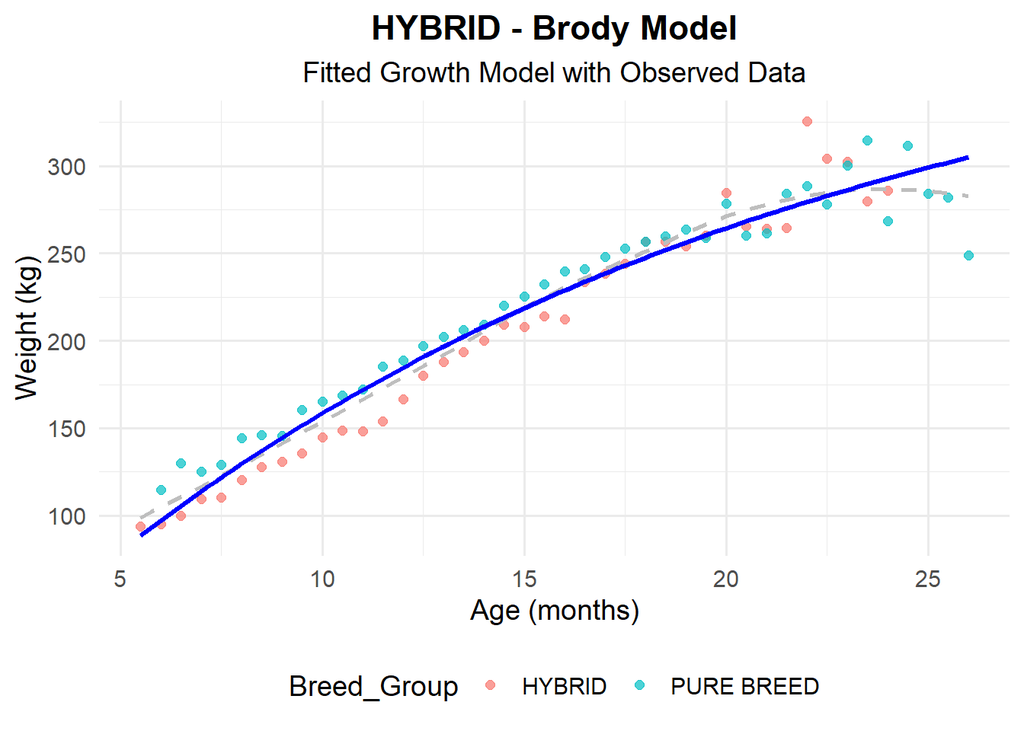

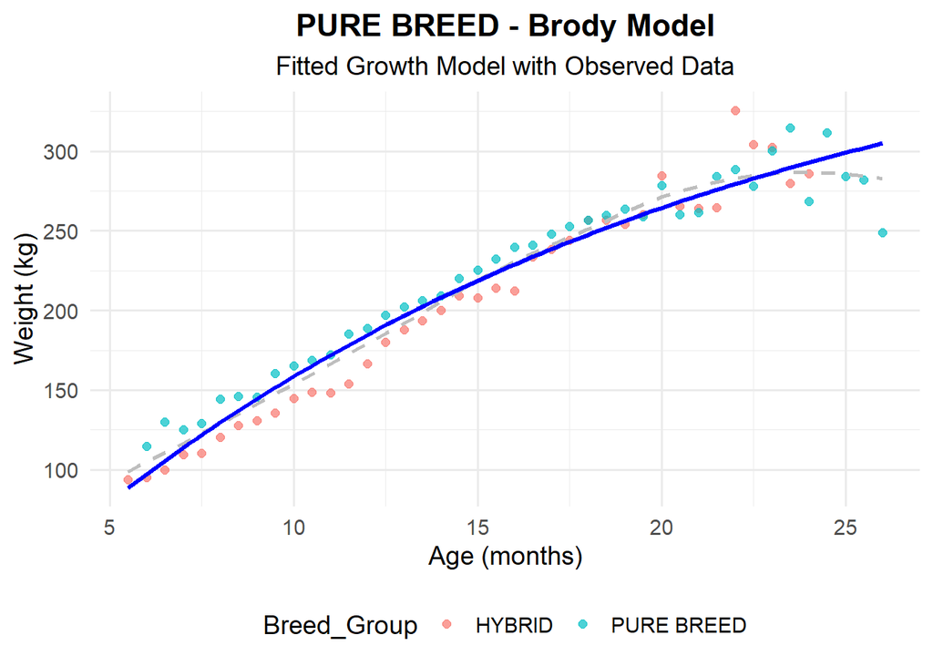

```r
for (plot_data in plots$brody_plot) print(plot_data)
```

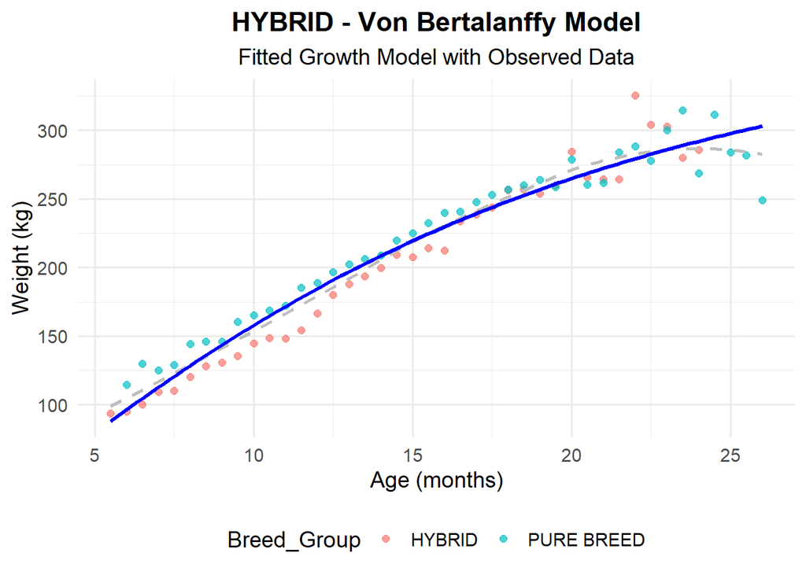

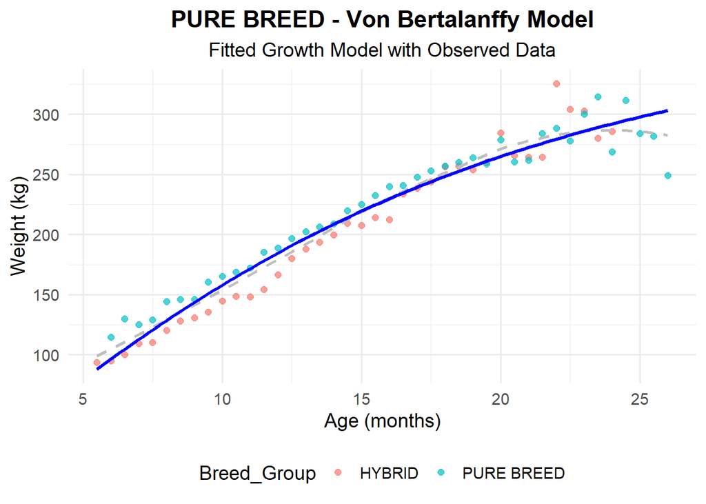

```r
for (plot_data in plots$vonB_plot) print(plot_data)
```

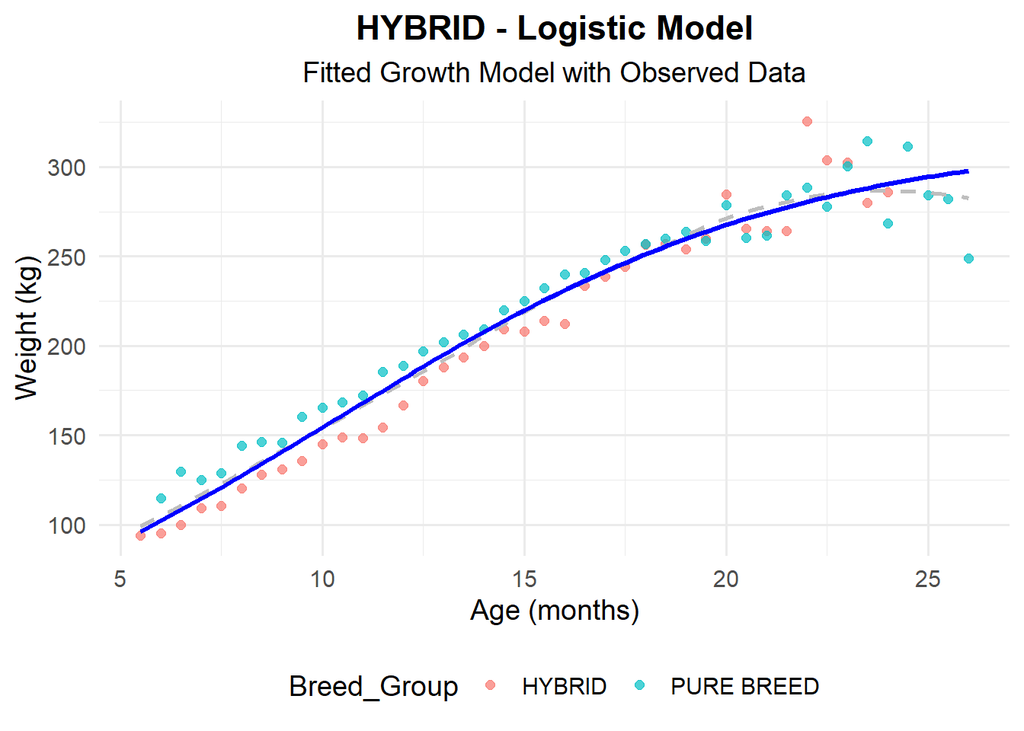

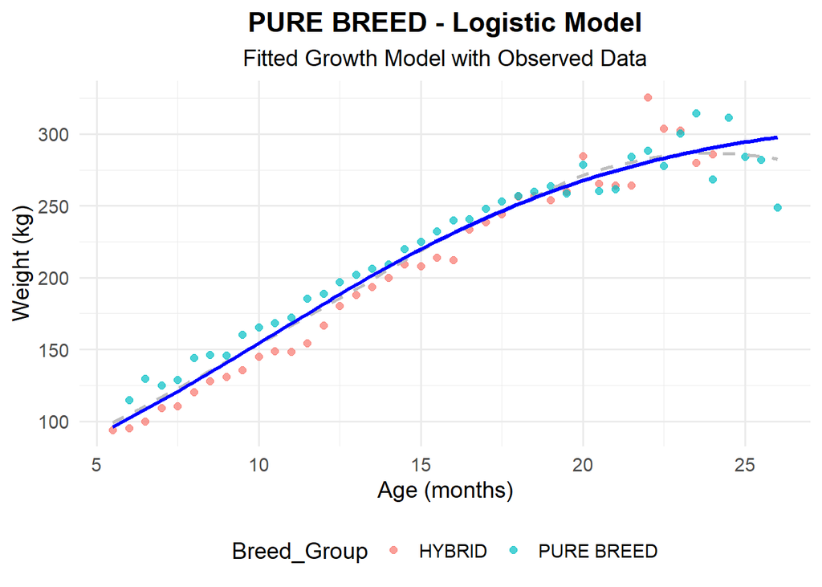

```r
for (plot_data in plots$log_plot) print(plot_data)
```